# Clase 1 - Árboles de decisión

# El problema

El eje de estas clases va a ser predecir si la participación de las personas en el trabajo doméstico del hogar, en base a los resultados de la Encuesta de Uso del Tiempo (2021). Vamos a tomar como insumo la variable `TCS_GRUPO_DOMESTICO` para construir una variable dicotómique define si las personas realizan trabajo doméstico en el hogar o no. `TCS_GRUPO_DOMESTICO` son los minutos totales dedicados a las actividades de trabajo doméstico en un día, independientemente de si se realizó otra actividad en simultáneo.

## Importación y preprocesamiento de los datos

Primero, vamos vamos a leer la base, recodificar algunas variables y generar nuestra variable dicotómica **Y**.

```r
library(tidyverse)

data <- read_delim("./data/enut2021_base.txt", delim = "|")

data <- data %>% select(ID, SEXO_SEL, EDAD_SEL, TCS_GRUPO_DOMESTICO, CONDICION_ACTIVIDAD_AGRUPADA,
                        NIVEL_EDUCATIVO_AGRUPADO, CANT_DEMANDANTES_TOTAL, CANT_NODEMANDANTES_TOTAL,
                        BHCH04_SEL, BHDC_SEL) %>%
  mutate(realiza_domest = as.factor(case_when(
    TCS_GRUPO_DOMESTICO > 60 ~ "Realiza",
    TRUE ~ "No realiza")))

data <- data %>% mutate_at(
                   vars(SEXO_SEL),
                    ~as.factor(case_when(
                      . == 1 ~ "Mujer",
                      . == 2 ~ "Varón"
                    )))


 data <- data %>% mutate_at(vars(CONDICION_ACTIVIDAD_AGRUPADA),
                   ~as.factor(case_when(
                     . == 1 ~ "Ocupado",
                     . == 2 ~ "No ocupado"
                   )))

data <- data %>% mutate_at(vars(BHCH04_SEL),
                   ~as.factor(case_when(
                     . == 1 ~ "Jefe/a",
                     . == 2 ~ "Cónyuge/pareja",
                     . == 3 ~ "Hijo/a",
                     . == 4 ~ "Hijastro/a",
                     . == 5 ~ "Yerno/nuera",
                     . == 6 ~ "Nieto/a",
                     . == 7 ~ "Padre o madre",
                     . == 8 ~ "Suegro/a",
                     . == 9 ~ "Hermano/a",
                     . == 10 ~ "Cuñado/a",
                     . == 11 ~ "Sobrino/a",
                     . == 12 ~ "Abuelo/a",
                     . == 13 ~ "Otro familiar",
                     . == 14 ~ "Otro no familiar")))



 data <- data %>% mutate_at(vars(BHDC_SEL),
                   ~as.factor(case_when(
                     . == 0 ~ "No es demandante de cuidado",
                     . == 1 ~ "Es demandante de cuidado"
                   )))

data <- data %>% select(-TCS_GRUPO_DOMESTICO)
```

Luego, vamos a importar tidymodels, que es el paquete que vamos a estar usando para trabajar con modelos:

```r
library(tidymodels)
```

¿Cuántos valores tenemos de cada caso?

```r
summary(data$realiza_domest)
```

```
## No realiza    Realiza
##       4686       9664
```

# Modelado

## Partición train/test

Lo próximo a hacer para empezar el modelo es crear una partición de datos en train y test. Recuerden que esto es muy importante, ya que queremos entrenar el modelo con nuestro conjunto de datos pero también queremos ver cómo funcionaría con datos nuevos.

```r
set.seed(123)

split <- initial_split(data)
train <- training(split)
test <- testing(split)

table(train$realiza_domest)
```

```
##
## No realiza    Realiza
##       3508       7254
```

## Feature engineering

Nuestra muestra está bastante *desbalanceada*, pero nos vamos a encargar de ello ahora en el workflow.

A continuación, procesamos las variable haciendo la “receta” del modelo. Con `recipe()` especificamos un set de transformaciones que queremos hacer sobre el modelo. Su principal argumento es la fórmula del modelo, que en nuestro caso es `realiza_domest ~ .`. También vamos a usar `step_other()` para agrupar las categorías de relación con jefe de hogar minoritarias. Por último, para controlar el desbalanceo de clases vamos a usar la función `step_downsample()` del paquete themis. Lo que hace step_downsample es eliminar las filas del dataset de la clase que está sobrerepresentada (en este caso, realiza), para que nos quede una proporción similar de casos de cada clase.

```r
library(themis)
recipe <- recipe(realiza_domest ~ ., data = train)%>%
  update_role(ID, new_role = "id") %>%
  step_other(BHCH04_SEL, threshold = 0.2)%>%
  step_downsample(realiza_domest, under_ratio = 1)
```

A continuación, vamos a construir el `workflow()`de trabajo. Repasemos que en un workflow puedo juntar en preprocesamiento, modelado y funciones de post-modelado. Le agrego la receta que hicimos con `add_recipe`.

```r
wf <- workflow() %>%
  add_recipe(recipe)
```

## Tuneando los hiperparámetros

Como a priori no tengo forma de saber qué combinación de hiperparámetros es mejor para mi caso, tengo que hacer una prueba con varios a través de cross-validation y ver cuál funciona mejor. Por eso, en este workflow primero voy a crear un árbol de decisión con parámetros “vacíos”. Únicamente les vamos a pasar la función `tune()`, con la cual le damos a entender a tidymodels que vamos a pasar y probar una serie de distintos parámetros para el árbol de decisión.

```r
tree_spec <- decision_tree(
  cost_complexity = tune(),
  tree_depth = tune(),
  min_n = tune()
) %>%
  set_engine("rpart") %>%
  set_mode("classification")

tree_spec %>% translate()
```

```
## Decision Tree Model Specification (classification)
##
## Main Arguments:
##   cost_complexity = tune()
##   tree_depth = tune()
##   min_n = tune()
##
## Computational engine: rpart
##
## Model fit template:
## rpart::rpart(formula = missing_arg(), data = missing_arg(), weights = missing_arg(),
##     cp = tune(), maxdepth = tune(), minsplit = min_rows(tune(),
##         data))
```

Una vez instanciado el modelo, lo metemos en el workflow.

```r
tree_wf <- wf %>%
  add_model(tree_spec)
```

- `cost_complexity():` es un número que recorta los nodos del árbol, empezando por aquellos que tengan la mayor pureza. Postpoda.
- `tree_depth():` es un número que define la máxima cantidad de particiones que puede llegar a tener el modelo. Prepoda.
- `min_n():` mínimo número de puntos que debe haber en un nodo para que el árbol se siga partiendo hacia abajo. Prepoda.

```r
set.seed(1912)

tree_grid <- grid_regular(cost_complexity(), tree_depth(), min_n(), levels = 4)

tree_grid
```

```
## # A tibble: 64 × 3
##    cost_complexity tree_depth min_n
##              <dbl>      <int> <int>
##  1    0.0000000001          1     2
##  2    0.0000001             1     2
##  3    0.0001                1     2
##  4    0.1                   1     2
##  5    0.0000000001          5     2
##  6    0.0000001             5     2
##  7    0.0001                5     2
##  8    0.1                   5     2
##  9    0.0000000001         10     2
## 10    0.0000001            10     2
## # ℹ 54 more rows
```

Hacemos las muestras de cross-validation…

```r
set.seed(111)

folds <- vfold_cv(train, v = 10)

tidy(folds)
```

```
## # A tibble: 107,620 × 3
##      Row Data     Fold
##    <int> <chr>    <chr>
##  1     1 Analysis Fold01
##  2     1 Analysis Fold02
##  3     1 Analysis Fold03
##  4     1 Analysis Fold05
##  5     1 Analysis Fold06
##  6     1 Analysis Fold07
##  7     1 Analysis Fold08
##  8     1 Analysis Fold09
##  9     1 Analysis Fold10
## 10     2 Analysis Fold01
## # ℹ 107,610 more rows
```

Ahora vamos a probar los posibles valores que puede adoptar el modelo con los distintos parámetros en las muestras con cross-validation.

```r
doParallel::registerDoParallel()

set.seed(345)

tree_rs <- tree_wf %>%
  tune_grid(
  resamples = folds,
  grid = tree_grid,
  metrics = metric_set(roc_auc, precision,
                       recall, f_meas)
)
```

Podemos ver los resultados de este objeto con `collect_metrics()`.

```r
collect_metrics(tree_rs)
```

```
## # A tibble: 256 × 9
##    cost_complexity tree_depth min_n .metric   .estimator  mean     n std_err
##              <dbl>      <int> <int> <chr>     <chr>      <dbl> <int>   <dbl>
##  1    0.0000000001          1     2 f_meas    binary     0.541    10 0.00472
##  2    0.0000000001          1     2 precision binary     0.469    10 0.00451
##  3    0.0000000001          1     2 recall    binary     0.639    10 0.00795
##  4    0.0000000001          1     2 roc_auc   binary     0.645    10 0.00512
##  5    0.0000001             1     2 f_meas    binary     0.541    10 0.00472
##  6    0.0000001             1     2 precision binary     0.469    10 0.00451
##  7    0.0000001             1     2 recall    binary     0.639    10 0.00795
##  8    0.0000001             1     2 roc_auc   binary     0.645    10 0.00512
##  9    0.0001                1     2 f_meas    binary     0.541    10 0.00472
## 10    0.0001                1     2 precision binary     0.469    10 0.00451
## # ℹ 246 more rows
## # ℹ 1 more variable: .config <chr>
```

### Evaluación del training set

Con la función `autoplot()` podemos hacer de manera sencilla un gráfico que nos visualice las métricas de cada una de las variantes del modelo.

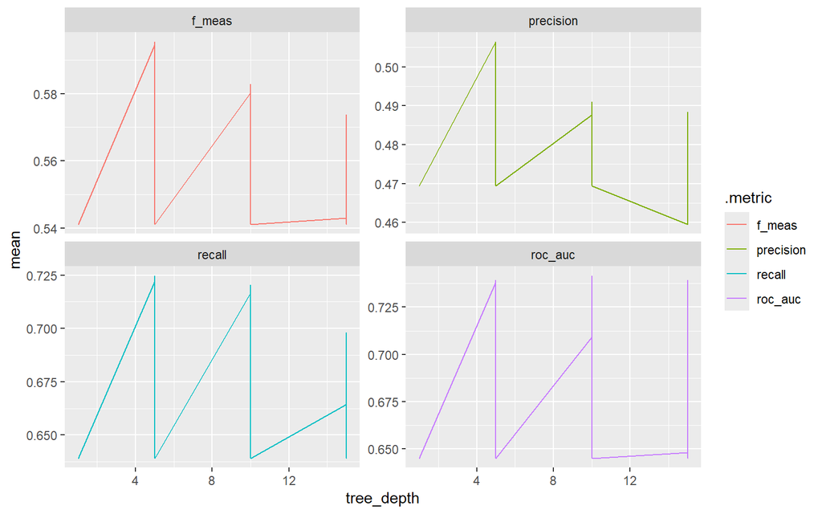

```r
autoplot(tree_rs)
```

Parecería que este dataset funciona mejor con un árbol no tan complejo. Podemos seguir examinando el mejor set de parámetros según la métrica que queramos.

```r
tree_rs %>%
  show_best(metric = "roc_auc", n = 5)
```

```
## # A tibble: 5 × 9
##   cost_complexity tree_depth min_n .metric .estimator  mean     n std_err
##             <dbl>      <int> <int> <chr>   <chr>      <dbl> <int>   <dbl>
## 1    0.0000000001         10    40 roc_auc binary     0.742    10 0.00515
## 2    0.0000001            10    40 roc_auc binary     0.742    10 0.00515
## 3    0.0001               10    40 roc_auc binary     0.741    10 0.00494
## 4    0.0000000001         15    40 roc_auc binary     0.739    10 0.00529
## 5    0.0000001            15    40 roc_auc binary     0.739    10 0.00529
## # ℹ 1 more variable: .config <chr>
```

E incluso podemos elegir el mejor modelo de esas pruebas cross-validation para implementar en el modelo final.

```r
best_model <- select_best(tree_rs, metric= "roc_auc")

final_tree <- finalize_model(tree_spec, best_model)

final_tree
```

```
## Decision Tree Model Specification (classification)
##
## Main Arguments:
##   cost_complexity = 1e-10
##   tree_depth = 10
##   min_n = 40
##
## Computational engine: rpart
```

Hasta acá, el modelo está actualizado y finalizado (no lo podemos seguir tuneando con distintos parámetros). Pero nos resta *fitearlo* al dataset de entrenamiento, lo que vamos a hacer con la función `fit()`.

```r
final_fit <- tree_wf %>% update_model(final_tree) %>% fit(train)

final_fit
```

```
## ══ Workflow [trained] ══════════════════════════════════════════════════════════
## Preprocessor: Recipe
## Model: decision_tree()
##
## ── Preprocessor ────────────────────────────────────────────────────────────────
## 2 Recipe Steps
##
## • step_other()
## • step_downsample()
##
## ── Model ───────────────────────────────────────────────────────────────────────
## n= 7016
##
## node), split, n, loss, yval, (yprob)
##       * denotes terminal node
##
##    1) root 7016 3508 No realiza (0.50000000 0.50000000)
##      2) SEXO_SEL=Varón 3447 1207 No realiza (0.64984044 0.35015956)
##        4) EDAD_SEL< 50.5 2340  656 No realiza (0.71965812 0.28034188)
##          8) BHCH04_SEL=other 933  174 No realiza (0.81350482 0.18649518)
##           16) EDAD_SEL< 19.5 316   33 No realiza (0.89556962 0.10443038) *
##           17) EDAD_SEL>=19.5 617  141 No realiza (0.77147488 0.22852512)
##             34) EDAD_SEL< 33.5 468   96 No realiza (0.79487179 0.20512821)
##               68) CANT_NODEMANDANTES_TOTAL>=3.5 217   37 No realiza (0.82949309 0.17050691) *
##               69) CANT_NODEMANDANTES_TOTAL< 3.5 251   59 No realiza (0.76494024 0.23505976)
##                138) CONDICION_ACTIVIDAD_AGRUPADA=Ocupado 181   38 No realiza (0.79005525 0.20994475) *
##                139) CONDICION_ACTIVIDAD_AGRUPADA=No ocupado 70   21 No realiza (0.70000000 0.30000000)
##                  278) EDAD_SEL< 21.5 23    2 No realiza (0.91304348 0.08695652) *
##                  279) EDAD_SEL>=21.5 47   19 No realiza (0.59574468 0.40425532)
##                    558) NIVEL_EDUCATIVO_AGRUPADO>=3.5 23    6 No realiza (0.73913043 0.26086957) *
##                    559) NIVEL_EDUCATIVO_AGRUPADO< 3.5 24   11 Realiza (0.45833333 0.54166667) *
##             35) EDAD_SEL>=33.5 149   45 No realiza (0.69798658 0.30201342) *
##          9) BHCH04_SEL=Cónyuge/pareja,Jefe/a 1407  482 No realiza (0.65742715 0.34257285)
##           18) CONDICION_ACTIVIDAD_AGRUPADA=Ocupado 1337  441 No realiza (0.67015707 0.32984293)
##             36) CANT_NODEMANDANTES_TOTAL>=1.5 959  294 No realiza (0.69343066 0.30656934) *
##             37) CANT_NODEMANDANTES_TOTAL< 1.5 378  147 No realiza (0.61111111 0.38888889)
##               74) EDAD_SEL< 48.5 349  130 No realiza (0.62750716 0.37249284)
##                148) CANT_DEMANDANTES_TOTAL< 0.5 321  114 No realiza (0.64485981 0.35514019) *
##                149) CANT_DEMANDANTES_TOTAL>=0.5 28   12 Realiza (0.42857143 0.57142857) *
##               75) EDAD_SEL>=48.5 29   12 Realiza (0.41379310 0.58620690) *
```

[output cut: 9 more lines]

```
##               80) EDAD_SEL< 68.5 80   19 No realiza (0.76250000 0.23750000) *
##               81) EDAD_SEL>=68.5 13    6 Realiza (0.46153846 0.53846154) *
##             41) CANT_DEMANDANTES_TOTAL>=0.5 24   11 Realiza (0.45833333 0.54166667) *
##           21) BHCH04_SEL=Jefe/a,other 534  233 No realiza (0.56367041 0.43632959)
##             42) CANT_NODEMANDANTES_TOTAL>=4.5 22    7 No realiza (0.68181818 0.31818182) *
##             43) CANT_NODEMANDANTES_TOTAL< 4.5 512  226 No realiza (0.55859375 0.44140625)
##               86) EDAD_SEL< 59.5 277  116 No realiza (0.58122744 0.41877256)
##                172) EDAD_SEL>=58.5 35    9 No realiza (0.74285714 0.25714286) *
##                173) EDAD_SEL< 58.5 242  107 No realiza (0.55785124 0.44214876)
##                  346) CANT_NODEMANDANTES_TOTAL< 2.5 162   64 No realiza (0.60493827 0.39506173)
##                    692) NIVEL_EDUCATIVO_AGRUPADO< 3.5 98   33 No realiza (0.66326531 0.33673469) *
##                    693) NIVEL_EDUCATIVO_AGRUPADO>=3.5 64   31 No realiza (0.51562500 0.48437500)
##
## ...
## and 106 more lines.
```

Este print nos muestra un bloque de texto con los nodos y distintas ramas. Sin embargo, también podemos visualizar las variables más importantes del modelo con el paquete `vip`. Con su función podemos mostrar de forma sencilla la importancia de las variables del modelo en un gráfico de columnas, puntos, boxplot o violin plot. Sin embargo, hay que tener en cuenta una cosa: este paquete funciona con **modelos**, no con workflows. Por eso vamos a usar la función `extract_fit_parsnip` para extraer nuestro modelo del workflow y aplicar vip sobre él.

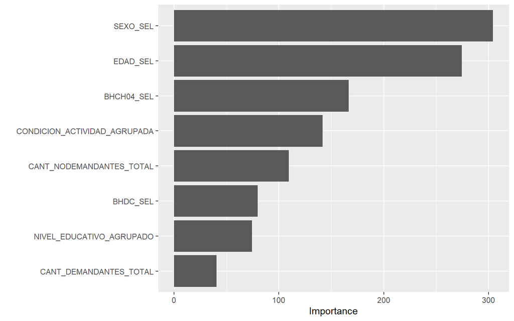

```r
library(vip)
extract_fit_parsnip(final_fit) %>%
  vip(geom = "col")
```

Podemos ver que las variables más importantes para explicar si se realiza trabajo doméstico o no son `SEXO_SEL`, `EDAD_SEL` `BHCH04_SEL`, la relación con el jefe de hogar.

También podemos graficarlo con la librería `rpart.plot`. El código acá se hace un poco más choclo, porque tenemos que llamar la misma función para extraer el modelo pero además llamar al objeto `fit` dentro de eso.

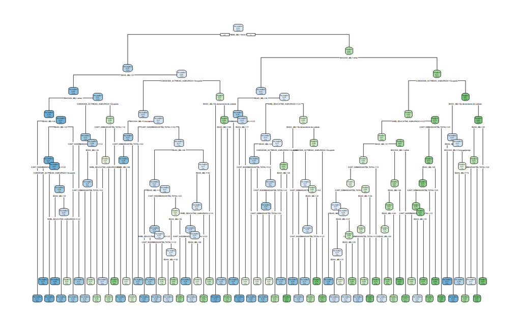

```r
library(rpart.plot)


rpart.plot(extract_fit_parsnip(final_fit)$fit)
```

# Evaluación

Ahora bien, el último paso sería probar esto en el set de validación o test set. Usamos `predict()` para predecir con el modelo los valores de el dataset de testeo, y con `bind_cols()` lo agregamos como una columna.

```r
test <- final_fit %>%
  predict(test) %>%
  bind_cols(test, .)
```

¿Cómo vemos las metricas de evaluación? Usamos la funcion `metric_set()`, donde podemos pasar las métricas que queremos ver y lo creamos en un objeto. Luego, a ese objeto le pasamos el dataset, los valores reales y los valores predichos.

```r
class_metrics <- metric_set(precision, accuracy,
                            recall, f_meas)

class_metrics(test, truth = realiza_domest, estimate = .pred_class)
```

```
## # A tibble: 4 × 3
##   .metric   .estimator .estimate
##   <chr>     <chr>          <dbl>
## 1 precision binary         0.531
## 2 accuracy  binary         0.698
## 3 recall    binary         0.693
## 4 f_meas    binary         0.601
```

En base a lo visto durante el contenido teórico, ¿qué nos dice cada una de estas métricas sobre el modelo? ¿Cómo se interpretan?

```r
matriz_confusion <- conf_mat(test,truth = realiza_domest, estimate = .pred_class)

matriz_confusion
```

```
##             Truth
## Prediction   No realiza Realiza
##   No realiza        816     722
##   Realiza           362    1688
```

También podemos graficar la curva ROC. Primero hay que obtener las probabilidades de predicción para cada clase:

```r
test <- final_fit %>%
  predict(test, type = "prob") %>%
  bind_cols(test, .)

test %>% select(realiza_domest:.pred_Realiza)
```

```
## # A tibble: 3,588 × 4
##    realiza_domest .pred_class `.pred_No realiza` .pred_Realiza
##    <fct>          <fct>                    <dbl>         <dbl>
##  1 Realiza        Realiza                  0.345         0.655
##  2 No realiza     No realiza               0.645         0.355
##  3 Realiza        Realiza                  0.358         0.642
##  4 No realiza     Realiza                  0.436         0.564
##  5 No realiza     Realiza                  0.490         0.510
##  6 No realiza     No realiza               0.645         0.355
##  7 Realiza        Realiza                  0.286         0.714
##  8 Realiza        Realiza                  0.133         0.867
##  9 Realiza        Realiza                  0.490         0.510
## 10 Realiza        Realiza                  0.358         0.642
## # ℹ 3,578 more rows
```

Graficamos la curva ROC pasando el valor real y la probabilidad de predicción.

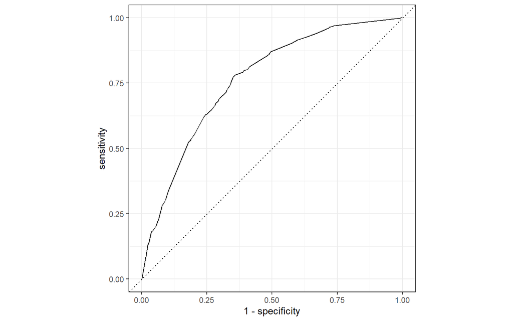

```r
test %>%
  roc_curve(truth = realiza_domest, ".pred_No realiza") %>%
  autoplot()
```

Para obtener una métrica normalizada, usamos roc_auc para obtener el valor del área debajo de la curva.

```r
test %>%
  roc_auc(truth = realiza_domest, ".pred_No realiza")
```

```
## # A tibble: 1 × 3
##   .metric .estimator .estimate
##   <chr>   <chr>          <dbl>
## 1 roc_auc binary         0.763
```